# SQL - Lenguaje de Consulta Estructurado

Fusion de Tablas

César Mignoni

# Introducción

Hasta el momento se han ralizado consultas **SQL** operando una sola tabla de datos, sin embargo, muchas veces es necesario obtener una consulta cuyas filas tengan datos provenientes de tablas independientes, por ejemplo, obtener los empleados y que en la misma fila de empleados aparezca el departamento y dirección la sucursal donde trabaja. En este material se estudiarán este tipo de consultas basadas en la combinación o unión (JOIN) de tablas. La unión de tablas consiste en obtener a partir de dos tablas cualesquiera una nueva tabla fusionando las filas de una con las filas de la otra.

Conceptualmente, cuando se especifican dos conjuntos de datos, **SQL** hace coincidir cada fila del primero con todas las filas del segundo para producir un resultado conocido como *producto cartesiano*. El *producto cartesiano* de grandes conjuntos de datos puede ser excesivamente grande, por lo cual, este tipo de operación no es la que se utiliza más a menudo, lo más apropiado sería obtener una salida que sea un subconjuntos de datos declarando el tipo de combinación.

# Combinación de tablas

## Combinación interna

La *Combinación interna* devuelve como salida a todas las filas de la tabla de la isquierda que tienen una o más filas coincidentes en la tabla de la derecha. Realiza la busqueda de coincidencias entre las dos tablas en función a una columna que tienen en común. De tal modo que en el resultado sólo se mostrará la intersección.

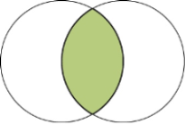

## Combinaciones externas

Las **Combinaciones externas** son combinaciones internas que se incrementan con las filas que no coinciden con ninguna fila de la otra tabla en la combinación. Hay tres tipos de combinaciones externas: izquierda, derecha y completa.

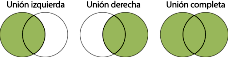

### Combinación izquierda

Comunmente llamada *LEFT JOIN* en **SQL** (*Unión izquierda*), es un tipo de *combinación externa* en la que la salida resultante incluye todas las observaciones de la tabla izquierda, independientemente de que se encuentre una coincidencia en la tabla especificada a la derecha. Esta combinación se representa en el siguiente diagrama.

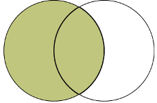

### Combinación derecha

Se la conoce como *RIGHT JOIN* en **SQL** (*unión derecha*). Es idéntica a la *unión izquierda*, excepto que el resultados incluye todas las observaciones de la tabla derecha, si se encuentra o no una coincidencia para ellas en la tabla de la izquierda. Una combinación derecha entre dos tablas se puede representar gráficamente como se muestra en el siguiente diagrama.

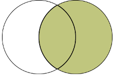

### Combinacion completa

Esta combinación es conocida como *Full (outer) Join* en **SQL** (*Unión completa*). En este tipo de unión la consulta resultante incluye todas las observaciones de ambas tablas para las cuales haya coincidencia, más las filas de cada tabla que no coinciden con ninguna fila en la otra tabla. La representación visual de la unión completa se muestra en el siguiente diagrama.

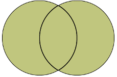

### Otras variantes

**Exclución interna Izquierda**

Esta consulta devolverá todos los registros de la tabla de la izquierda que no coincidan con ningún registro de la tabla de la derecha. La representación visual de esta unión semuestra en el siguiente diagrama:

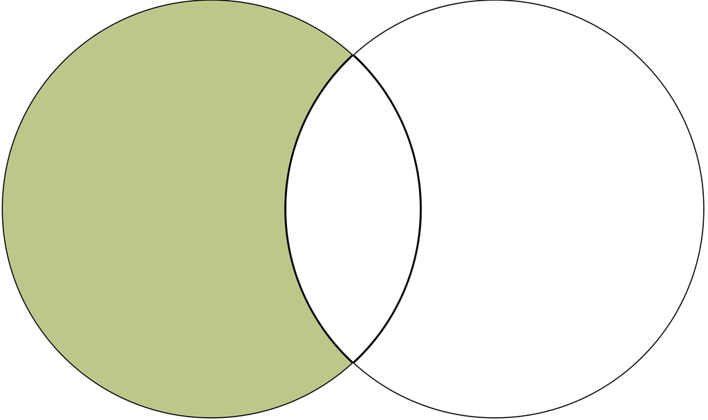

**Exclución interna derecha**

Esta consulta devolverá todos los registros de la tabla de la derecha que no coincidan conningún registro de la tabla de la izquierda. La representación visual de esta unión se muestra en el siguiente diagrama:

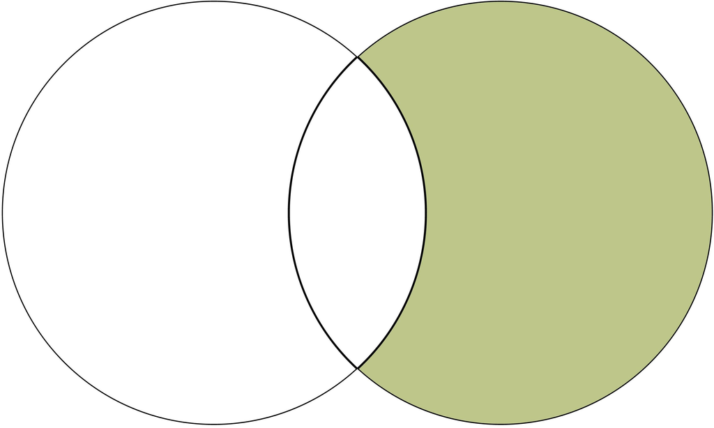

**Exclución interna exterior**

Esta consulta devolverá todos los registros de la tabla de la izquierda y todos los registros de la tabla de la derecha que no coincidan. La representación visual de esta unión se muestra en el siguiente diagrama:

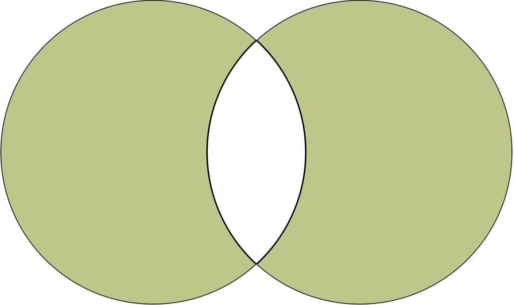

# Unión interna y externa de dataframe en R

## Función *merge()*

En **R**, se pueden combinar dos dataframe (conjunto de datos) usando la función *merge()*. Como requisito, los conjuntos de datos deben tener los mismos nombres en las columnas que se utilizan para realizar la unión. La función *merge()* en **R** es similar a la operación de unión de tablas con **SQL**. Los diferentes argumentos para *merge()* permiten realizar combinaciones internas, así como las combinaciones externas izquierda, derecha y completa.

## Argumentos

Los argumentos de la función *merge()* son:

- **“x”** : dataframe_1.
- **“y”** : dataframe_2.
- **“by”** , **“x”** , **“by.y”** : los nombres de las columnas que son comunes a **“x”** e **“y”** . El valor predeterminado es usar las columnas con nombres comunes entre los dos conjuntos de datos.
- **“all, all.x, all.y”** : valores lógicos que especifican el tipo de unión. El valor predeterminado es *“all=FALSE”* (lo que significa que solo se devuelven las filas coincidentes).

### Definición de argumentos

A continuación se describe como deben escribirse los argumentos en la función *merge()* para obtener los diferentes tipos de unión:

- *Unión interna* : para mantener solo las filas que coinciden con los conjuntos de datos, especifique el argumento **“all=FALSE”**.
- *Unión completa*: para mantener todas las filas de ambos conjuntos de datos, se especifica **“all=TRUE”**.
- *Unión izquierda*: para incluir todas las filas del conjunto de datos de la izquierda **“x”** y solo aquellas filas del de la derecha **“y”** que coincidan, se especifica **“all.x=TRUE”**.
- *Unión derecha*: para incluir todas las filas del conjunto de datos de la derecha **“y”** y solo las filas del de la izquierda **“x”** que coinciden, se especifica **“all.y=TRUE”** .

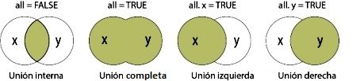

Argumentos función merge

## Ejemplos prácticos

Primero se definien dos conjuntos de datos que serán la base para los ejemplos posteriores. Por un lado, la tabla *Empleados* que almacena una lista de empleados y el id del departamento al que pertenecen:

**Empleados**

```
##       Nombre departamentoID
## 1   Rafferty             31
## 2      Jones             33
## 3 Heisenberg             33
## 4   Robinson             34
## 5      Smith             34
## 6   Williams             NA
```

Y por otro lado, la tabla *Departamentos* con la lista de departamentos que existen en la empresa.

**Departamentos**

```
##   departamentoID      Nombre
## 1             31       Sales
## 2             33 Engineering
## 3             34    Clerical
## 4             35   Marketing
```

### Unión interna

En el ejemplo, se quiere listar los empleados e indicar el nombre del departamento al que pertenecen, se reliza lo siguiente:

```r
df <- merge(x = df1, y = df2, by = "departamentoID")
```

Con este comando el resultado es:

```
##   departamentoID   Nombre.x    Nombre.y
## 1             31   Rafferty       Sales
## 2             33      Jones Engineering
## 3             33 Heisenberg Engineering
## 4             34   Robinson    Clerical
## 5             34      Smith    Clerical
```

Y apartir del resultado se puede observar que:

- El empleado “Williams” no aparece en los resultados, ya que no pertenece a ningún departamento existente.
- También, hay que tener en cuenta que, en el listado resultante se ven 3 columnas, las 2 primeras corresponden a la tabla Empleados y la última a Departamentos.

### Unión completa

En este ejemplo se encarga de mostrar todas las filas de ambas tablas, sin importar que noexistan coincidencias (usará *NA* como un valor por defecto para dichos casos).

```r
df <- merge(x = df1, y = df2, by = "departamentoID", all = TRUE)
```

Como resultado muestra la siguiente lista:

```
##   departamentoID   Nombre.x    Nombre.y
## 1             31   Rafferty       Sales
## 2             33      Jones Engineering
## 3             33 Heisenberg Engineering
## 4             34   Robinson    Clerical
## 5             34      Smith    Clerical
## 6             35       <NA>   Marketing
## 7             NA   Williams        <NA>
```

Se puede observar al empleado “Williams” a pesar de que no está asignado a ningún departamento, y se muestra el departamento de “Marketing” sin que tenga algun empleado trabajando en él.

### Unión izquierda

Para este ejemplo, la tabla *Empleados* es la primera tabla que aparece en la consulta (df1), por lo tanto es la tabla izquierda, y todas sus filas se mostrarán en los resultados.

La tabla *Departamentos* es la tabla de la derecha (df2) y si se encuentran coincidencias se mostrarán los valores correspondientes, pero sino, aparecerá NA en los resultados.

```r
df <- merge(x = df1, y = df2, by = "departamentoID", all.x = TRUE)
```

El resultado es:

```
##   departamentoID   Nombre.x    Nombre.y
## 1             31   Rafferty       Sales
## 2             33      Jones Engineering
## 3             33 Heisenberg Engineering
## 4             34   Robinson    Clerical
## 5             34      Smith    Clerical
## 6             NA   Williams        <NA>
```

### Unión derecha

En el siguiente ejemplo, la tabla *Departamentos* es la segunda tabla que aparece en la consulta (df2), es la tabla de la derecha y se verán todas sus filas.

La tabla *Empleados* es la tabla de la izquierda (df1) y si se encuentran coincidencias se mostrarán los valores correspondientes, pero sino, aparecerá NA en los resultados.

```r
df <- merge(x = df1, y = df2, by = "departamentoID", all.y = TRUE)
```

Entonces el resultado mostrará todos los departamentos al menos una vez. Y si no hay ningún empleado trabajando en un departamento determinado, se mostrará NA. Pero el departamento igual aparecerá.

```
##   departamentoID   Nombre.x    Nombre.y
## 1             31   Rafferty       Sales
## 2             33      Jones Engineering
## 3             33 Heisenberg Engineering
## 4             34   Robinson    Clerical
## 5             34      Smith    Clerical
## 6             35       <NA>   Marketing
```

### Combinación cruzada

También conocida como *CROSS JOIN* en **SQL** (*producto cartesiano*), da como resultado que cada fila de una tabla se una a cada fila de otra tabla.

```r
df<-merge(x = df1, y = df2, by = NULL)
```

El conjunto de datos resultante será:

```
##     Nombre.x departamentoID.x departamentoID.y    Nombre.y
## 1   Rafferty               31               31       Sales
## 2      Jones               33               31       Sales
## 3 Heisenberg               33               31       Sales
## 4   Robinson               34               31       Sales
## 5      Smith               34               31       Sales
## 6   Williams               NA               31       Sales
## 7   Rafferty               31               33 Engineering
## 8      Jones               33               33 Engineering
```

| *Nota*: una vez obtenido el conjunto de datos mediante la union de dos o mas tablas, es posible seleccionar las variables de interes utilizando la función *sqldf()*. |
| --- |

# Unión interna y externa de dataset en SAS

## Procedimiento PROC SQL

El procedimiento *PROC SQL* implementa el lenguaje de consulta estructurado estándar en **SAS** y también permite al usuario la unión de *dataset* mediante consultas de combinación. En el procedimiento *PROC SQL* la cláusula *FROM* se utiliza en una expresión de consulta para especificar el/los conjunto(s) de datos fuente, y que se combinan para producir el resultado de la unión. La cláusula *WHERE* o la cláusula *ON* contienen las condiciones bajo las cuales algunas filas son consideradas o desestimadas del resultado. *WHERE* se usa para seleccionar filas de uniones internas. *ON* se utiliza para seleccionar filas de uniones internas o externas.

## Ejemplos prácticos

### Unión interna

```r
Proc sql;
  title "Empleados por Departamento";
  SELECT *
  FROM datos.Empleados E,
       Datos.Departamentos D
       WHERE E.DepartamentoId = D.DepartamentoId
  ORDER BY E.nombre desc;
quit;
```

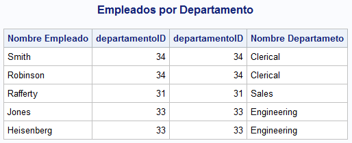

### Unión izquierda

```r
proc sql;
    SELECT *
    FROM datos.Empleados E LEFT JOIN
         Datos.Departamentos D
         ON E.DepartamentoId = D.DepartamentoId
    ORDER BY E.nombre;
quit;
```

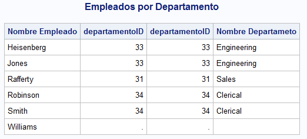

### Unión derecha

```r
proc sql;
SELECT *
    FROM datos.Empleados as E RIGHT JOIN
         Datos.Departamentos as D
         ON E.DepartamentoId = D.DepartamentoId
    ORDER BY D.nombre;
quit;
```

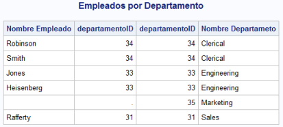

### Unión completa

```r
proc sql;
  SELECT *
  FROM datos.Empleados as E FULL JOIN
       Datos.Departamentos as D
       ON E.DepartamentoId = D.DepartamentoId;
quit;
```

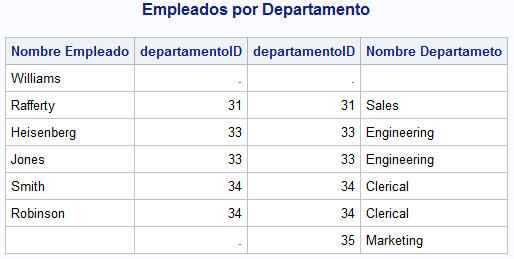

Para todos los ejemplo vistos hasta aquí en **SAS**, si la intesión es crear un dataset con el resultado de la consulta en particular, basta con agregar la linea de comando: *create table … as;* antes de de la sentencia *SELECT*.